# NEPA Decarbonization Technology Analysis: Deliverable 6

## Pipeline Identification

Pipeline projects are identified using the controlled-vocabulary `project_type` field: a project receives the pipeline tag (`project_is_pipeline`) if its `project_type` contains *Pipeline*. This mirrors the geothermal identification approach — type-tag-only, with no free-text keyword sweep of project titles or descriptions. The result is a universe of 5,324 pipeline-tagged NEPA projects across all technology groups.

**A new-build filter further narrows the pipeline universe for duration analyses.** Because the broad keyword gate captures the full lifecycle of pipeline-related NEPA activity — new construction, expansions, operational modifications, safety certifications, right-of-way renewals, and administrative approvals — mixing all of these into duration comparisons would conflate genuinely new infrastructure reviews with routine regulatory filings. A two-gate new-build filter (`project_is_pipeline_new_build`) is applied to isolate likely construction reviews for that purpose:

1. **Build-text gate** (applied to project title + description): the project contains explicit construction language — e.g., *new pipeline*, *construct/build/install/lay pipeline*, *pipeline project/route/corridor/expansion/segment/lateral*.
2. **Maintenance exclusion** (applied to title only): the project title does not contain maintenance language — e.g., *pipeline inspection*, *cathodic protection*, *pigging*, *pipeline repair/maintenance*, *routine inspection*, *leak detection*.

No length threshold is applied (unlike transmission’s ≥ 1 mile gate) because pipeline length coverage is substantially sparser; requiring a length would discard many genuine new-build projects that lack an extractable length value.

**Carbon and hydrogen pipelines are exempted from the build-text gate.** These represent nascent infrastructure: nearly all of their NEPA reviews are for genuinely new projects (CCS corridors, CCUS facilities, liquefaction terminals, hydrogen conveyance systems) rather than operational or maintenance filings. Applying the build-text gate to them would incorrectly exclude large integrated energy projects whose NEPA title describes the broader facility rather than the pipeline component specifically. The maintenance exclusion still applies. As a result, 98% of carbon and hydrogen pipeline projects (183 of 187) pass the new-build filter. For natural gas and oil/petroleum pipelines — which have large existing infrastructure bases generating routine operational NEPA filings — the build-text gate is required and only 17% of all pipeline projects (899 of 5,324) are classified as new-build.

**Note**

The new-build filter is applied specifically to duration analyses (length vs. duration scatter, length-band duration violin). All other figures — length distributions, technology group breakdowns, and the pipeline identification funnel — use the full 5,324 pipeline-tagged universe.

Figure 16 shows the identification path from the full NEPATEC 2.0 corpus through the pipeline tag, the new-build filter, and finally the decarbonization technology subset.

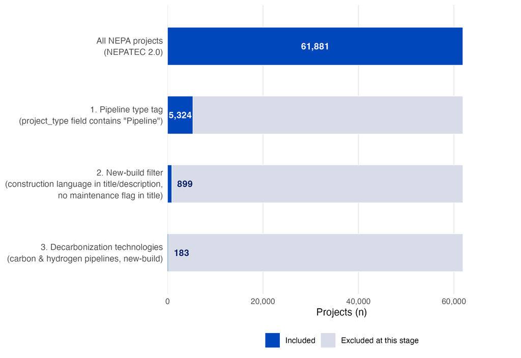

Figure 16: Pipeline project identification. Stage 1: NEPATEC project_type field contains ‘Pipeline’. Stage 2: new-build filter (construction language in title/description, no maintenance flag in title; carbon and hydrogen pipelines exempted from the build-text requirement). Stage 3: decarbonization technology subset (carbon and hydrogen pipelines passing the new-build filter).

### Pipeline Length

Pipeline length is extracted from the same metadata fields used for tagging (project title, description, and project type). Unlike transmission length extraction — which searches NEPA document pages as a fallback when metadata lacks a length value — pipeline length is derived from **metadata alone**. Pattern-based rules identify numeric mileage candidates in the text; when multiple plausible values are present, a priority cascade selects the best one, preferring explicit phrasing such as “X miles long” or “X-mile pipeline” over incidental numeric mentions.

There is no LLM adjudication step for pipelines. Transmission length adjudication uses a Claude-based model to resolve ambiguous multi-candidate cases (e.g., distinguishing a segment length from a total corridor length); no equivalent step was run for pipelines. This, combined with the metadata-only search scope, means pipeline length coverage is substantially sparser than for transmission.

Figure 17 shows what fraction of the 5,324 pipeline-tagged projects have an extractable length value.

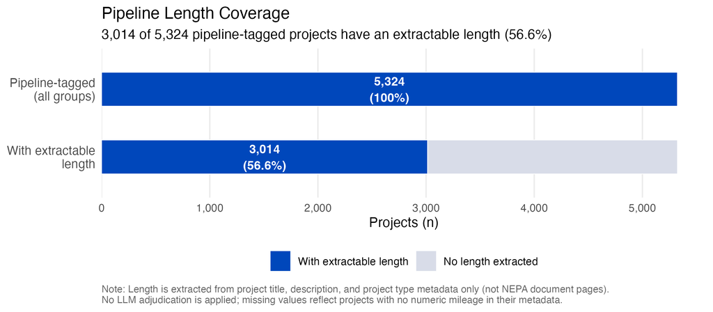

Figure 17: Pipeline length coverage. Of all pipeline-tagged projects, only a fraction carry an explicit numeric length in their metadata. Percentage shown inside each bar.

Of the 3,014 projects with an extractable length, a further subset also have calculable NEPA durations (both an initiation and a decision date); length–duration analyses draw only on this smaller intersection.

### Technology Groups and Decarbonization Status

The 5,324 pipeline NEPA projects span six technology groups:

- **Carbon pipeline**: pipeline tag + keyword match for *carbon*, *CO₂*, *carbon dioxide*, *CCS*, *carbon capture*, or *carbon sequestration*.
- **Hydrogen pipeline**: pipeline tag + keyword match for *hydrogen*.
- **Natural gas pipeline**: pipeline tag + keyword match for *natural gas*, *gas pipeline*, *gas gathering*, or *gas line*.
- **Oil/petroleum pipeline**: pipeline tag + controlled-vocabulary `project_type` includes “Oil & Gas,” “Oil and Gas,” or “Petroleum.”
- **Water/irrigation pipeline**: pipeline tag + controlled-vocabulary `project_type` includes “Water Resources” or “Irrigation” (and not Oil & Gas).
- **Other pipeline**: all remaining projects carrying the pipeline tag but unmatched by any of the above classifiers.

For this analysis, carbon and hydrogen pipelines are treated as **decarbonization technologies** — overriding the NEPATEC energy type tag, which classifies both as “Fossil fuel” in the source data. This reflects that CCS infrastructure and low-carbon hydrogen are policy-relevant decarbonization technology investments regardless of their association with fossil fuel systems. Natural gas and oil/petroleum pipelines are classified as **fossil fuel**; water/irrigation and other pipelines are classified as **Other**.

Figure 18 shows the project counts by group, colored by this classification.

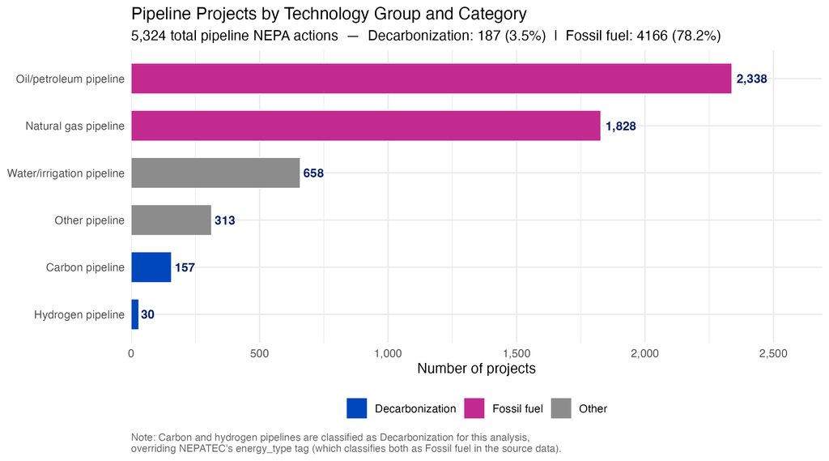

Figure 18: Pipeline NEPA actions by technology group and decarbonization classification. Blue = decarbonization (carbon + hydrogen); pink = fossil fuel (natural gas + oil/petroleum); grey = other. Carbon and hydrogen pipelines are reclassified as Decarbonization for this analysis; NEPATEC’s energy_type tag labels both as Fossil fuel.

## Pipeline Length Distribution

Figure 19 shows the overall distribution of extracted pipeline lengths across all groups combined, topcoded at 50 miles. The distribution is heavily right-skewed: the great majority of projects with a recoverable length are short — under 5 miles — with a long upper tail of interstate corridors and large-scale transmission systems. The dashed line marks the overall median.

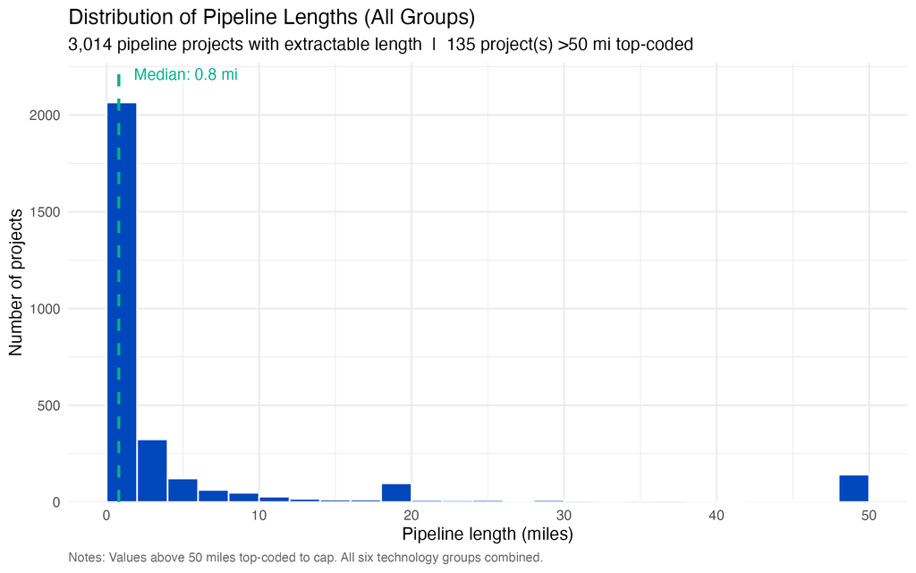

Figure 19: Distribution of extracted pipeline lengths (miles) across all six technology groups. Dashed line marks the overall median. Values above 50 miles are top-coded.

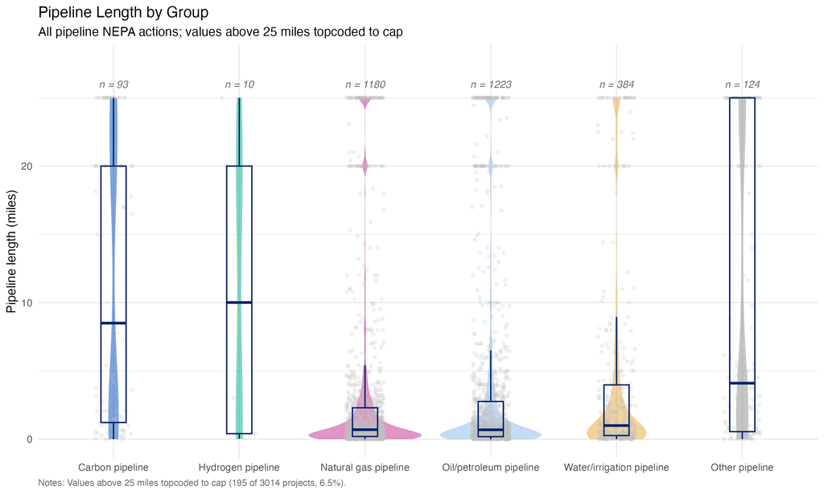

Figure 20: Pipeline length by technology group (violin + box + jitter). All pipeline NEPA projects with an extractable length are shown. Values above 25 miles are topcoded to 25 and appear at the cap rather than being dropped. n labels show the number of projects with a usable length figure per group.

## Pipeline Length vs. NEPA Duration

Duration analyses in this section use the **new-build subset** (899 projects) rather than the full pipeline-tagged universe. This avoids conflating construction reviews with operational/maintenance filings in the duration comparisons.

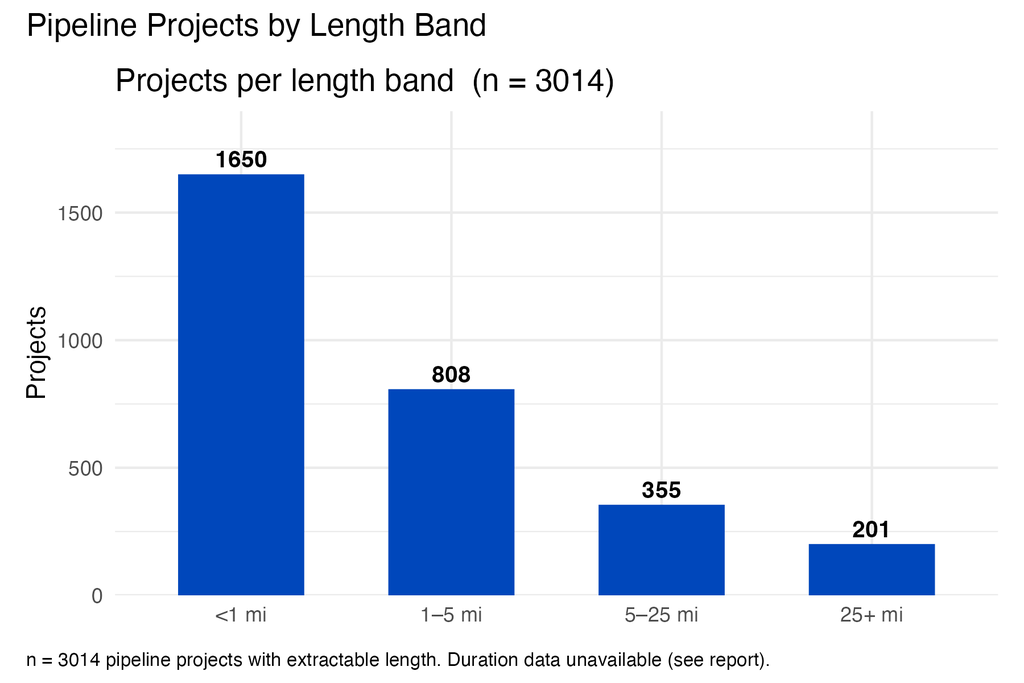

[figure not shown]